[figure not shown]

# Inferência Bayesiana em R

##### Giuliano Netto Flores Cruz Março, 2020

# Introdução

Quando pensamos em aprender sobre o mundo a partir da coleta de dados, estamos pensando em *inferência*. A inferência é um tipo de raciocínio por meio do qual saímos de simples amostras para generalizações em termos de uma população (1). Alternativamente, podemos entendê-la como uma ponte de via oposta àquela da probabilidade: enquanto que a última liga um processo de geração de dados aos valores observados, a primeira sai de dados observados para tentar estimar o referido processo (Fig. 1).

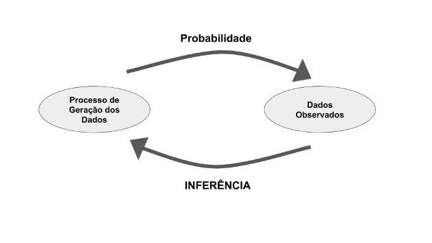

**Fig. 1:** Inferência é um tipo de raciocínio que liga amostras às populações, isto é, dados observados aos processos responsáveis por gerá-los. Adaptado de (2) - pág. IX.

Utilizando uma linguagem mais próxima à ciência da computação, chamamos de inferência estatística ou *aprendizado* o processo de usar dados para inferir a distribuição que gerou estes mesmos dados (2) - daí, também, termos populares em data science como *learning*, *statistical learning*, *machine learning*, etc. Dada uma amostra $X_1, X_2, \dots, X_n \overset{i.i.d.}{\thicksim} \mathcal{F_0}$, tipicamente estamos preocupados em descobrir $\mathcal{F_0}$ (ou um conjunto de características de $\mathcal{F_0}$, *e.g.*, sua média) utilizando um modelo estatístico (ver Nota 1).

**Nota 1 - Modelo Estatístico**:

Seja $X_1, X_2, \dots, X_n$ uma amostra de $n$ variáveis aleatórias independentes e igualmente distribuídas. Um modelo estatístico associado (paramétrico) é o par:

$$(E,\ \{\mathcal{F}_{\theta}\}_{\theta \in \Theta})$$
em que:

- $E$ é o espaço amostral, o qual contém todos os desfechos possíveis para $X$;
- $\{\mathcal{F}_{\theta}\}_{\theta \in \Theta}$ é uma família de distribuições de probabilidade em $E$;
- $\Theta$ é o espaço paramétrico contendo todos os parâmetros possíveis $\theta \in \Theta$ que indexam $\mathcal{F}_{\theta}$.

Por exemplo, o jogar de uma moeda pode ser modelado a partir da distribução de Bernoulli, em que $E = \{0,1\}$, $\Theta = \{\theta \in \mathbb{R}:\ 0 < \theta < 1\} = (0,1)$ e $\mathcal{F}_{\theta} = \mathcal{Ber}(\theta)$. O presente modelo pode ser definido, portando, como:

$$(\{0,1\}, \{\mathcal{Ber}(\theta)\}_{\theta \in (0,1)})$$

Assumindo que $X$ segue uma distribuição $F_0$ desconhecida, uma vez que temos $(E,\ \{F_{\theta}\}_{\theta \in \Theta})$, o processo de inferência trata, por exemplo, de achar $\widehat{\theta}$ tal que $\mathcal{F}_{\widehat{\theta}}$ aproxima $\mathcal{F_0}$. Nesse caso, $\hat{\theta}$ é uma estimativa pontual de um **parâmetro** $\theta$ que indexa $\mathcal{F_0}$. Inferência não paramétrica ocorre quando não podemos definir um número finito de parâmetros que indexam a família $\{F_{\theta}\}_{\theta \in \Theta}$. No caso da distribuição de Bernoulli, $\theta \in (0,1)$ é um escalar (dimensão igual a 1); no caso não paramétrico, a dimensão de $\theta$ não possui valor finito.

Nesse contexto, há duas grandes “escolas” que merecem destaque: clássica e bayesiana. Embora foquemos na segunda, é didático termos um overview da primeira a fim de deixar claras as suas diferenças.

## Inferência Clássica

Também conhecida como *frequentista*, é rotulada como clássica por sua predominância durante a primeira metade do século passado, impulsionada por seus tradicionais fundadores, como Karl Pearson e Ronald A. Fisher (3). De acordo com (2), trabalha em cima de três principais postulados:

- Probabilidade se refere a frequências relativas limites, como propriedades objetivas do mundo real. Ex: a probabilidade de resultar cara ao jogar de uma moeda é a frequência relativa de resultados cara observados em $n$ jogos no limite $n \rightarrow \infty$.
- Parâmetros são constantes fixas desconhecidas. Como não flutuam (não vão variáveis aleatórias), nenhuma afirmação probabilística sobre parâmetros faz sentido, *e.g.*, “existe 95% de probabilidade de o parâmetro $\mu$ pertencer ao intervalo $[A, B]$”.
- Statistical procedures should be designed to have well-defined long run frequency properties. For example, a 95 percent confidence interval should trap the true value of the parameter with limiting frequency at least 95 percent.

# Referências

1. Douglas C. Montgomery GCR. *Estatistica aplicada e probabilidade para engenheiros*. 6th ed. LTC (2016).

2. Wasserman L. *All of statistics: A concise course in statistical inference (springer texts in statistics)*. Springer New York (2004).

3. Carlos Daniel Paulino BM M. Antonia Amaral Turkman. *Estatística bayesiana*. 2nd ed. Fundação Calouste Gulbenkian (2018).